# National Esthetics Written Practical Examination CIB

## CANDIDATE INFORMATION BULLETIN (CIB)

**EXAMINATION CONTENT AND IMPORTANT INSTRUCTIONS**

*Please visit your official examination provider website OR www.nictesting.org for the most current bulletin prior to testing.*

The National Esthetics Written Practical Examination is a licensure examination for Esthetics, developed by the National-Interstate Council of State Boards of Cosmetology (NIC).

This bulletin contains IMPORTANT INFORMATION regarding National Esthetics Written Practical Examination content and administration for core services and additional sections and references.

The time allowed for this examination is 60 minutes.

*PLEASE REVIEW ALL INFORMATION CAREFULLY.*

For each NIC National Written Practical Examination, there are multiple parts to every Candidate Information Bulletin (CIB):

- **Important Instructions and Examination Content Domain Sections** – This provides information and guidelines related to administration of the Written Practical examination and information about the scope of content covered in the Written Practical examination.
- **References** – This provides a list of references used to develop and support the content covered in NIC examinations. References will be the same across exam types for each exam.

*BE CERTAIN TO REVIEW ALL PARTS OF THIS NIC EXAMINATION CIB CAREFULLY!*

## IMPORTANT INSTRUCTIONS

### General

- Do not leave the examination area without permission. Permission must be obtained to leave the examination area for any reason, including restroom usage or at the completion of the examination. *Picture ID is required for re-entry into the examination.*
- All examinations are administered in a testing environment.

### Standardized Administration

Due to standardization of the NIC National Examinations, proctors and examiners are required to adhere to the following standards:

- With the exception of verbal instructions, proctors and examination administration personnel are NOT allowed to speak with candidates.
- If a candidate experiences an emergency situation, they may notify the proctor by raising their hand.

#### Prohibited Items

- The following provides examples of materials and actions that are prohibited in the examination room during the examination administration:
  - Possession of cellular phones, watches (of any kind), pagers, tablets, computers, projectors, cameras, or any other electronic or recording devices, printed materials, or handwritten notes.
  - Purses, bags, coats, hats, and any other personal items not directly needed to complete the examination, are not allowed.
- Communicating to other candidates or any examiner.
- Exhibiting disruptive behavior. The above referenced items or actions are not an exhaustive list.

Failure to comply with any of these conditions or exhibiting ANY behavior that suggests an effort to cheat will result in immediate dismissal from the examination and the candidates’ actions reported to the proper authorities.

## ESTHETICS WRITTEN PRACTICAL EXAMINATION CONTENT OUTLINE

### Domain Details

The following outlines the scope of content covered by the NIC National Esthetics Written Practical Examination. The percentages represent the percentage of items from each domain. The examination contains 120 items, of which 70 items are weighted and contribute to the candidate’s final score.

1. Scientific Concepts (35%)
   1. Apply knowledge of infection control procedures
   2. Apply knowledge of safety procedures and guidelines related to:
      1. Standard (Universal) Precautions
      2. Blood exposure procedures
      3. Handling of chemicals
   3. Recognize and understand skin disorders and diseases related to:
      1. Disorders of the sebaceous gland (e.g., acne, millia, seborrhea)
      2. Disorders of the sudoriferous gland (e.g., hyperhidrosis, bromhidrosis, anhidrosis)
      3. Contagious diseases (e.g., bacterial conjunctivitis, herpes simplex, tinea)
      4. Skin inflammations (e.g., dermatitis, eczema, rosacea)
      5. Skin pigmentation (i.e., hyperpigmentation, hypopigmentation)
      6. Skin growths (e.g., skin tags, moles, keratoma)
      7. Skin cancers (i.e., basal cell carcinoma, squamous cell carcinoma, melanoma)
   4. Understanding function and composition of the hair related to:
      1. Abnormal hair growth (e.g., hirsutism, hypertrichosis)
   5. Understanding basic chemistry as related to:
      1. Function (e.g., hydration, protection, cleanse)
      2. Acidity/Alkalinity (i.e., pH)
2. SKIN CARE AND SERVICES (65%)
   1. Demonstrate an understanding of performing a client consultation and documentation
   2. Apply knowledge of client protection (i.e., draping of head and body)
   3. Skin analysis (e.g., Fitzpatrick skin types/conditions/characteristics)
   4. Contraindications for skin services
   5. Treatment protocol
   6. Demonstrate an understanding of cleansing procedures
   7. Demonstrate an understanding of steaming procedures
   8. Demonstrate an understanding of exfoliation procedures (i.e., chemical, mechanical/manual)
   9. Demonstrate a basic understanding of massage movements
   10. Demonstrate an understanding of methods of extraction
   11. Demonstrate an understanding of the functions and applications of masks
   12. Demonstrate an understanding of the conclusion of facial services
   13. Demonstrate a basic knowledge of the use of electrical equipment used in skin services
   14. Demonstrate an understanding of makeup as related to:
       1. Product selection (e.g., lipstick, foundation)
       2. Application (e.g., contouring, highlighting, blending)
       3. Safety (e.g., bracing)
   15. Demonstrate a basic knowledge of other services related to:
       1. Facial services (e.g., aromatherapy, pre- and post-surgical/medical treatments, ultrasonic)
       2. Body treatments (body wraps, body scrubs, sunless tanning)
       3. Eyelash and eyebrow services (e.g., lash and brow tinting, artificial lashes, lash lifting/perming)
       4. Demonstrate an understanding of hair removal methods and procedures (i.e., waxing, tweezing)

## NATIONAL ESTHETICS WRITTEN PRACTICAL EXAMINATION SAMPLE QUESTIONS

1. During extractions, the implement falls to the floor. What should the practitioner do next?

   A. Pick up the implement, wash it, and continue with extractions

   B. Pick up the implement, place it in the “items to be disinfected” container, replace gloves, and continue with extractions

   C. Pick up the implement, place it on the workstation, wash hands, and continue with extractions

   D. Stop the service, disinfect the entire work area, replace gloves, and continue with extractions

2. An adolescent entering puberty has inquired about getting rid of blackheads and milia. The MOST effective way to clear up skin is

   A. the sale of multiple skin care products.

   B. daily treatments within the salon.

   C. the removal and cleansing of blemishes.

   D. chemicals and laser treatments.

3. When analyzing the skin through a Wood’s lamp, hyperpigmentation will appear

   A. blue.

   B. yellow.

   C. orange.

   D. brown

Answer Key

| Item | Key |
| --- | --- |
| 1 | B |
| 2 | C |
| 3 | D |
| 4 | C |
| 5 | C, E |

4. During the consultation, a client indicates they have vitiligo. How does this appear on the skin?

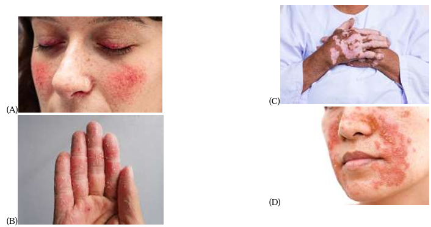

5. Select all images that show improper or no bracing during a makeup application.

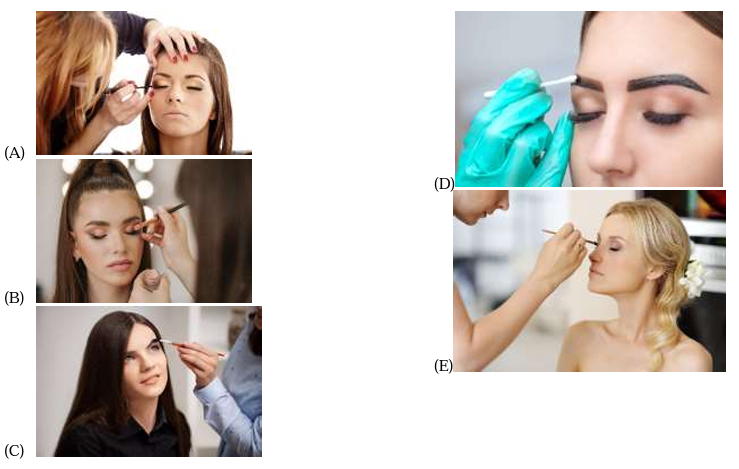

## NATIONAL-INTERSTATE COUNCIL OF STATE BOARDS OF COSMETOLOGY (NIC) REFERENCES

This list provides the references used to develop and support the content covered in the NIC National Esthetics examinations. References will be the same across exam types for each exam. Candidates are responsible for using these most updated versions of references, as these editions were used to reference test material.

Standard

*Milady Standard Esthetics Fundamentals*

Copyrighted Foundations 2020,

12th Edition

ISBN: 9780357263792

Milady www.Milady.com

Contact: Info@Milady.com;

*Pivot Point Fundamentals: Esthetics, (101E – 111E)*

Copyrighted ©2020 Pivot Point International, Inc.

1st Edition, 1st Printing, December 2020

ISBN 978-1-951862-26-8

Pivot Point International, Inc. https://www.pivot-point.com/shop/

Contact: info@pivot-point.com; 847-886-0500, Ext. 7399

Supplemental

*Milady Standard Advanced Esthetics*

Copyrighted 2013

2013, 2nd Edition

ISBN: 9781111139094

Milady www.Milady.com

Contact: Info@Milady.com;

*Salon Fundamentals Esthetics*

Copyrighted 2013

2013, 2nd Edition, 11th printing, 2nd Edition

August 2013 Pivot Point International, Inc. www.pivot-point.com

Contact: info@pivot-point.com; 847-886-0500, Ext. 7399

*The Epidermal Cell Therapy Skillsbook*

Copyrighted 2015

Author: L. Saphonia Gee, L.M.E., CIDESCO Diplomat L. Saphonia Gee

Copyright 2020 National-Interstate Council of State Boards of Cosmetology, Inc.